# TP1 Statistical Analysis and Document Mining

Karim Mike Rahhal, Othman Bensellam, Gwendal Cachim-Bernard

## Part1: Multiple linear regression on simulated data

#### 1.

```r
set.seed(0)
nrows=6000
ncols=201
Data=data.frame(matrix(rnorm(nrows*ncols), nrow=nrows))
head(Data)
```

|  | X1 | X2 | X3 | X4 | X5 | X6 | X7 | X8 | X9 | X10 | X11 | X12 | X13 | X14 | X15 | X16 | X17 | X18 | X19 | X20 | X21 | X22 | X23 | X24 | X25 | X26 | X27 | X28 | X29 | … |
| --- | --- | --- | --- | --- | --- | --- | --- | --- | --- | --- | --- | --- | --- | --- | --- | --- | --- | --- | --- | --- | --- | --- | --- | --- | --- | --- | --- | --- | --- | --- |
| 1 | 1.2629543 | -0.4210379 | -0.1984714 | 0.3403003 | -2.03557785 | -1.6106983 | -0.45257834 | 0.2662385 | 0.2390517 | 1.0929897 | 0.58447183 | 0.5867713 | -2.38735517 | 0.6983842 | 1.5871544 | -1.4552316 | -0.06483503 | 0.62069745 | -0.4254669 | 1.5013948 | 1.47149031 | -1.0477958 | -0.87535977 | 1.3863548 | -0.7367413 | -0.4369243 | 0.7657959 | 0.7215963 | 1.3992210 | … |
| 2 | -0.3262334 | -1.2714751 | 0.1498199 | -0.1874267 | 0.62856096 | 0.3783567 | 0.49951844 | -0.3290173 | 0.4788238 | 0.5408644 | -0.07573724 | 0.1956089 | -0.09335126 | -1.1350814 | 0.0591735 | 0.7698239 | 1.47013377 | 1.29944733 | 0.2514822 | -0.7203372 | 1.34303246 | 0.3393452 | -0.08395629 | -1.0128882 | -1.6130521 | -0.5822650 | 1.8343830 | -0.6763251 | -0.7961493 | … |
| 3 | 1.3297993 | 0.8393109 | -0.9205130 | 0.3787991 | -1.27350584 | -1.2570990 | 0.09445366 | -0.7020835 | 1.1077890 | -1.3377639 | -0.67335942 | -1.5971525 | -1.08399510 | 0.7706560 | -0.2156690 | -1.4679826 | -2.04793225 | 0.15816128 | 2.7489015 | -0.5092158 | -0.03217205 | -0.6550752 | 0.68901508 | -1.3048445 | -1.0380071 | -0.9104230 | -0.4100778 | -2.0083555 | 0.8767654 | … |
| 4 | 1.2724293 | 0.5400129 | -0.5952829 | -0.2933558 | -0.52957428 | -0.2540740 | 1.12977032 | -0.6332994 | 2.0082901 | 0.2155284 | 0.96146897 | -1.2657408 | 0.46158007 | -0.1095277 | -0.5642868 | 0.8515475 | 0.24464556 | 2.99838439 | -0.3540887 | 0.9209175 | -0.66324794 | 0.9887694 | -1.77443949 | 0.8507222 | -0.8597344 | 0.8063910 | 1.4432388 | -0.4937112 | -0.9987521 | … |
| 5 | 0.4146414 | 1.8679387 | -1.0171751 | -1.3553639 | -1.39802204 | 1.4356872 | -0.88168706 | 1.1107509 | -0.3641859 | -1.5348369 | -0.70523555 | 0.3125166 | -0.82217872 | -1.2460286 | -0.1173697 | 0.2075026 | -1.13710199 | 0.05937042 | -1.0292465 | -0.8353888 | -0.64007963 | 0.4194274 | 0.85185648 | 0.3098355 | 1.5449908 | 0.5163375 | 1.7887508 | 2.4014427 | 1.9817933 | … |
| 6 | -1.5399500 | 0.4445180 | 0.5891424 | 0.9973951 | 0.01898703 | 1.4030621 | 0.11156568 | 0.5012202 | -0.6156780 | -0.0694355 | -0.06542054 | -1.1015948 | -0.66656540 | 1.2198772 | -1.1348729 | 0.5318263 | -0.70049462 | -0.61749948 | -0.2638674 | -2.3434006 | 2.16249920 | 1.1191336 | -0.36209435 | -0.6397416 | -1.0158175 | -0.2360156 | -2.4717654 | 0.7617440 | 1.3362961 | … |

#### 2.

#### **Gaussian Regression Model:**

$$Y = \beta_{0} \begin{bmatrix} 1 \\ 1 \\ \vdots \\ 1 \end{bmatrix} + \sum_{i = 1}^{201}\beta_{i} X_{i} + \epsilon_{r} \\
Y=\begin{bmatrix} y_{1} \\ y_{2} \\ \vdots \\ y_{201} \end{bmatrix}$$

$\epsilon_{r}$ is the error term that follows a multivariate normal distribution Y is the first column of the data ( predicted variable)

#### **True Regression Model:**

$$Y = \epsilon$$
The true regression line is a realization from the true underlying statistical regression model. We never know the true regression line when working with real data. This is a population model. The estimated regression is our best guess using the ordinary least squares or maximum likelihood estimation technique. It is our best guess of the underlying population model.

#### 3.

```r
mod<-lm(Data)
pvalues<-summary(mod)$coefficients[,4]
significant_variables = subset(pvalues,pvalues<=0.05)
significant_variables
```

```
##         X94        X125        X136        X141        X148        X169
## 0.022582923 0.026816252 0.040500240 0.038852768 0.004224608 0.020772670
##        X172        X177        X200
## 0.001814059 0.002914717 0.041895505
```

We want to perform the following test to check the significant Variables that correspond to the significant predictors
$$\begin{cases} H_{0}: (\beta_{j})_{1,...201}=0 \\ \\ H_{1}: (\beta_{j})_{1,...201} \neq 0 \end{cases}$$

After checking the p-values for all the predictors We concluded that their are 9 coefficients assessed as significantly not zero (they correspond to **significant variables**) as having their p-value <= 0.05 which leads to a **rejection** in the **null hypothesis**.  
So we can see that some predictors seems correlated with the output but it is because of the important number of predictors. In fact, we saw before that no predictors were correlated with the output because we randomly created every data without any correlation. The lesson to get from that is that doing models with a lot of predictors will get us some correlation but we should be aware that it is maybe not really correlated. So we should always verify and ask us the right questions about the reasons of the correlations

#### 4.

```r
x1=rnorm(1000)
eps2=rnorm(1000)
x2=3*x1 + eps2
eps3=rnorm(1000)
deux=rep(2,1000)
y= x2 + x1 + deux + eps3
```

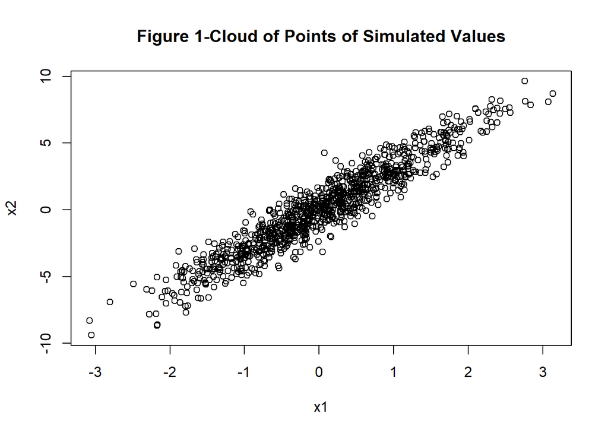

As we Can see in Figure 1 the shape is linear and one of the reasons is as being linear in it’s parameters.

```r
plot(x1,x2, main="Figure 1-Cloud of Points of Simulated Values")
```

$$\begin{cases} X_{1}=\epsilon_{1} \\ \\X_{2}=3\epsilon_{1} + \epsilon_{2} \end{cases}$$

$$\begin{equation} \tag{1} \begin{bmatrix} X_{1} \\ X_{2} \\ \end{bmatrix} = \begin{bmatrix} 1 & 0 \\ 3 & 1 \\ \end{bmatrix} \begin{bmatrix} \epsilon_{1} \\ \epsilon_{2} \\ \end{bmatrix} \end{equation}$$

If we denote the following Equation (1) by $X=A \epsilon$ then $Cov(X)=A Cov(\epsilon) A^T = AA^T \sigma^2$  
So, $Cov(X)= \begin{bmatrix} 1 & 3 \\ 3 & 10 \\ \end{bmatrix} \sigma^2 = C$  
$Var(X_{1})= \sigma^2$  
$Var(X_{2})= 10\sigma^2$

**Joint distribution** of ($X_{1,i}$,$X_{2,i}$) follows the Normal distribution with mean $\begin{bmatrix} 0 \\ 0 \\ \end{bmatrix}$ and CoVariance matrix C.

#### 5.

```r
Model1<-lm(formula=y~x1)
Model2<-lm(formula=y~x2)
summary(Model1)
```

```
##
## Call:
## lm(formula = y ~ x1)
##
## Residuals:
##     Min      1Q  Median      3Q     Max
## -5.0203 -0.8801  0.0358  0.9690  4.4167
##
## Coefficients:
##             Estimate Std. Error t value Pr(>|t|)
## (Intercept)  2.01065    0.04371   45.99   <2e-16 ***
## x1           4.05262    0.04351   93.14   <2e-16 ***
## ---
## Signif. codes:  0 '***' 0.001 '**' 0.01 '*' 0.05 '.' 0.1 ' ' 1
##
## Residual standard error: 1.382 on 998 degrees of freedom
## Multiple R-squared:  0.8968, Adjusted R-squared:  0.8967
## F-statistic:  8676 on 1 and 998 DF,  p-value: < 2.2e-16
```

```r
summary(Model2)
```

```
##
## Call:
## lm(formula = y ~ x2)
##
## Residuals:
##     Min      1Q  Median      3Q     Max
## -4.0205 -0.7049  0.0432  0.7061  2.9802
##
## Coefficients:
##             Estimate Std. Error t value Pr(>|t|)
## (Intercept)  2.02616    0.03258   62.19   <2e-16 ***
## x2           1.29734    0.01013  128.12   <2e-16 ***
## ---
## Signif. codes:  0 '***' 0.001 '**' 0.01 '*' 0.05 '.' 0.1 ' ' 1
##
## Residual standard error: 1.03 on 998 degrees of freedom
## Multiple R-squared:  0.9427, Adjusted R-squared:  0.9426
## F-statistic: 1.642e+04 on 1 and 998 DF,  p-value: < 2.2e-16
```

```r
(summary(Model1)$sigma)**2 # value of sigma^2 of Model1
```

```
## [1] 1.909783
```

```r
(summary(Model2)$sigma)**2 # value of sigma^2 of Model2
```

```
## [1] 1.060963
```

##### If we write $Y_{i}$ in terms of $X_{1,i}$ we will have this equation: $$\begin{equation} \tag{2} Y_{i}=2+4X_{1,i} + \epsilon_{2,i} + \epsilon_{3,i} \end{equation}$$

##### If we write $Y_{i}$ in terms of $X_{2,i}$ we will have this equation: $$\begin{equation} \tag{3} Y_{i}=2+\frac{4}{3}X_{2,i} - \epsilon_{2,i} + \epsilon_{3,i} \end{equation}$$

```r
set.seed(3)
x1=rnorm(10)
eps2=rnorm(10)
x2=3*x1 + eps2
eps3=rnorm(10)
deaux=rep(2,10)
y= x2 + x1 + deaux + eps3
Model1A<-lm(formula=y~x1)
Model2B<-lm(formula=y~x2)
summary(Model1A)
```

```
##
## Call:
## lm(formula = y ~ x1)
##
## Residuals:
##     Min      1Q  Median      3Q     Max
## -1.4216 -0.5664 -0.3675  0.6896  1.8840
##
## Coefficients:
##             Estimate Std. Error t value Pr(>|t|)
## (Intercept)   1.3733     0.3258   4.215  0.00294 **
## x1            4.0861     0.3954  10.334 6.64e-06 ***
## ---
## Signif. codes:  0 '***' 0.001 '**' 0.01 '*' 0.05 '.' 0.1 ' ' 1
##
## Residual standard error: 1.027 on 8 degrees of freedom
## Multiple R-squared:  0.9303, Adjusted R-squared:  0.9216
## F-statistic: 106.8 on 1 and 8 DF,  p-value: 6.637e-06
```

```r
summary(Model2B)
```

```
##
## Call:
## lm(formula = y ~ x2)
##
## Residuals:
##     Min      1Q  Median      3Q     Max
## -1.3320 -0.3809 -0.0879  0.2556  1.7751
##
## Coefficients:
##             Estimate Std. Error t value Pr(>|t|)
## (Intercept)   1.7662     0.3292   5.365 0.000674 ***
## x2            1.4239     0.1370  10.397 6.34e-06 ***
## ---
## Signif. codes:  0 '***' 0.001 '**' 0.01 '*' 0.05 '.' 0.1 ' ' 1
##
## Residual standard error: 1.021 on 8 degrees of freedom
## Multiple R-squared:  0.9311, Adjusted R-squared:  0.9225
## F-statistic: 108.1 on 1 and 8 DF,  p-value: 6.344e-06
```

```r
(summary(Model1A)$sigma)**2
```

```
## [1] 1.054566
```

```r
(summary(Model2B)$sigma)**2
```

```
## [1] 1.042822
```

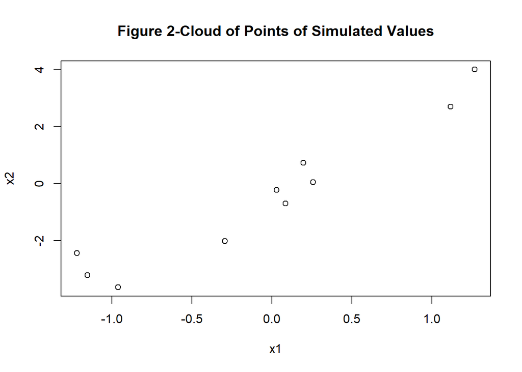

Figure 2 represents values of $x2$ calculated with the new seed by the new values of $x1$. There is only 10 values, but we can still see that the shape is linear.

```r
plot(x1,x2, main="Figure 2-Cloud of Points of Simulated Values")
```

- In addition to that we Can see the value of $\beta_{0}$ decreased in Both models due to the decrease in the number of points, but the value of $\beta_{1}$=4.0861 of Model 1 resulted in a slight increase and similarly the value of $\beta_{2}$=1.4239 also resulted in a slight increase.
- What we can conclude about the loss of precision is the size of the dataset should not be too small. Without enough data, the parameters will not be enough precise and will be more influenced by extreme cases.

#### 6.

```r
ModelA<-lm(formula=y~x1+x2)
summary(ModelA)
```

```
##
## Call:
## lm(formula = y ~ x1 + x2)
##
## Residuals:
##      Min       1Q   Median       3Q      Max
## -0.99896 -0.66387 -0.09066  0.71179  1.30298
##
## Coefficients:
##             Estimate Std. Error t value Pr(>|t|)
## (Intercept)   1.5812     0.3234   4.890  0.00177 **
## x1            2.0628     1.2974   1.590  0.15588
## x2            0.7336     0.4519   1.623  0.14855
## ---
## Signif. codes:  0 '***' 0.001 '**' 0.01 '*' 0.05 '.' 0.1 ' ' 1
##
## Residual standard error: 0.9357 on 7 degrees of freedom
## Multiple R-squared:  0.9494, Adjusted R-squared:  0.9349
## F-statistic: 65.63 on 2 and 7 DF,  p-value: 2.92e-05
```

## 1. Preliminary Analysis of the data

## (a)

```r
prostateCancer<-read.table("./prostate.data", header=TRUE)
head(prostateCancer)
```

|  | lcavol | lweight | age | lbph | svi | lcp | gleason | pgg45 | lpsa | train |
| --- | --- | --- | --- | --- | --- | --- | --- | --- | --- | --- |
| 1 | -0.5798185 | 2.769459 | 50 | -1.386294 | 0 | -1.386294 | 6 | 0 | -0.4307829 | TRUE |
| 2 | -0.9942523 | 3.319626 | 58 | -1.386294 | 0 | -1.386294 | 6 | 0 | -0.1625189 | TRUE |
| 3 | -0.5108256 | 2.691243 | 74 | -1.386294 | 0 | -1.386294 | 7 | 20 | -0.1625189 | TRUE |
| 4 | -1.2039728 | 3.282789 | 58 | -1.386294 | 0 | -1.386294 | 6 | 0 | -0.1625189 | TRUE |
| 5 | 0.7514161 | 3.432373 | 62 | -1.386294 | 0 | -1.386294 | 6 | 0 | 0.3715636 | TRUE |
| 6 | -1.0498221 | 3.228826 | 50 | -1.386294 | 0 | -1.386294 | 6 | 0 | 0.7654678 | TRUE |

```r
attach(prostateCancer)
colnames(prostateCancer)
```

```
##  [1] "lcavol"  "lweight" "age"     "lbph"    "svi"     "lcp"     "gleason"
##  [8] "pgg45"   "lpsa"    "train"
```

```r
pro=data.frame(lcavol,lweight,age,lbph,svi,lcp,gleason,pgg45,lpsa,train)
pro=pro[,-10]
head(pro)
```

|  | lcavol | lweight | age | lbph | svi | lcp | gleason | pgg45 | lpsa |
| --- | --- | --- | --- | --- | --- | --- | --- | --- | --- |
| 1 | -0.5798185 | 2.769459 | 50 | -1.386294 | 0 | -1.386294 | 6 | 0 | -0.4307829 |
| 2 | -0.9942523 | 3.319626 | 58 | -1.386294 | 0 | -1.386294 | 6 | 0 | -0.1625189 |
| 3 | -0.5108256 | 2.691243 | 74 | -1.386294 | 0 | -1.386294 | 7 | 20 | -0.1625189 |
| 4 | -1.2039728 | 3.282789 | 58 | -1.386294 | 0 | -1.386294 | 6 | 0 | -0.1625189 |
| 5 | 0.7514161 | 3.432373 | 62 | -1.386294 | 0 | -1.386294 | 6 | 0 | 0.3715636 |
| 6 | -1.0498221 | 3.228826 | 50 | -1.386294 | 0 | -1.386294 | 6 | 0 | 0.7654678 |

## (b)

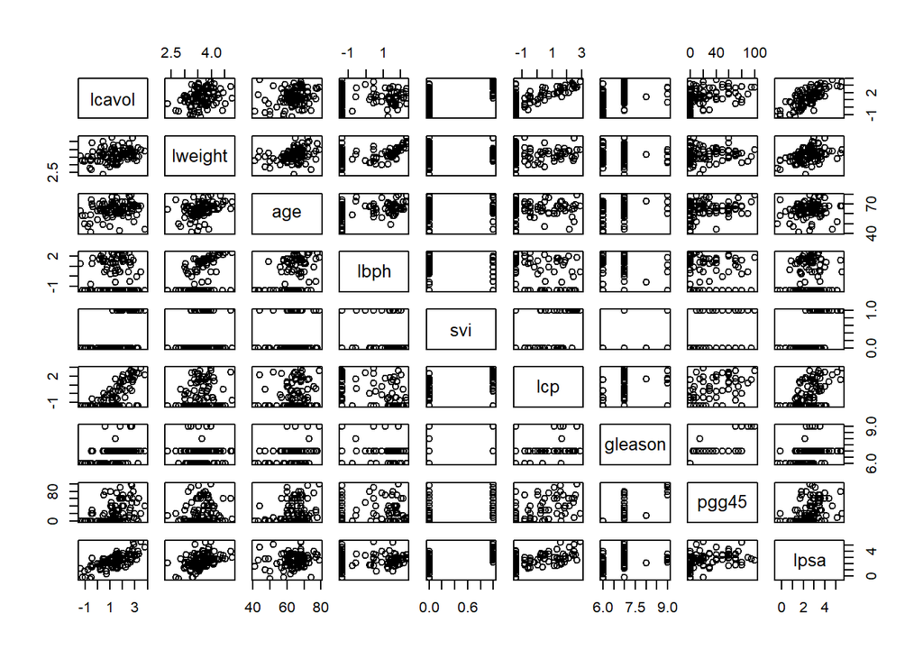

```r
pairs(pro)
```

```r
round(cor(pro), digits=2)
```

```
##         lcavol lweight  age  lbph   svi   lcp gleason pgg45 lpsa
## lcavol    1.00    0.28 0.22  0.03  0.54  0.68    0.43  0.43 0.73
## lweight   0.28    1.00 0.35  0.44  0.16  0.16    0.06  0.11 0.43
## age       0.22    0.35 1.00  0.35  0.12  0.13    0.27  0.28 0.17
## lbph      0.03    0.44 0.35  1.00 -0.09 -0.01    0.08  0.08 0.18
## svi       0.54    0.16 0.12 -0.09  1.00  0.67    0.32  0.46 0.57
## lcp       0.68    0.16 0.13 -0.01  0.67  1.00    0.51  0.63 0.55
## gleason   0.43    0.06 0.27  0.08  0.32  0.51    1.00  0.75 0.37
## pgg45     0.43    0.11 0.28  0.08  0.46  0.63    0.75  1.00 0.42
## lpsa      0.73    0.43 0.17  0.18  0.57  0.55    0.37  0.42 1.00
```

According to the graph of pairs command, the cloud of point that resemble more a line means that their are more correlation between the points. So,Based on the Correlation matrix and the scatter plots from pairs, we can see that *lcavol* and *lcp* are correlated with a positive correlation. In addition to that, *lcavol* and *lpsa* also have a strong positive correlation. Finally, *lcavol* and *svi* have a weak positive correlation.

## 2. Linear Regression

## (a)

```r
prostateCancer$gleason<-factor(prostateCancer$gleason)
prostateCancer$svi<-factor(prostateCancer$svi)
class(prostateCancer$gleason)
```

```
## [1] "factor"
```

```r
class(prostateCancer$svi)
```

```
## [1] "factor"
```

```r
model<- lm(formula= lcavol ~ lweight + age + lbph + prostateCancer$svi + lcp + prostateCancer$gleason + pgg45 + lpsa, data=pro)
summary(model)
```

```
##
## Call:
## lm(formula = lcavol ~ lweight + age + lbph + prostateCancer$svi +
##     lcp + prostateCancer$gleason + pgg45 + lpsa, data = pro)
##
## Residuals:
##      Min       1Q   Median       3Q      Max
## -1.91436 -0.48444 -0.02664  0.54915  1.80062
##
## Coefficients:
##                          Estimate Std. Error t value Pr(>|t|)
## (Intercept)             -1.406654   0.874455  -1.609   0.1114
## lweight                 -0.011246   0.211453  -0.053   0.9577
## age                      0.024782   0.011241   2.205   0.0301 *
## lbph                    -0.104200   0.058209  -1.790   0.0770 .
## prostateCancer$svi1     -0.220419   0.256351  -0.860   0.3923
## lcp                      0.402760   0.085074   4.734 8.58e-06 ***
## prostateCancer$gleason7  0.311676   0.215268   1.448   0.1513
## prostateCancer$gleason8 -0.710588   0.758827  -0.936   0.3517
## prostateCancer$gleason9  0.790135   0.487510   1.621   0.1087
## pgg45                   -0.009444   0.004540  -2.080   0.0405 *
## lpsa                     0.549573   0.090093   6.100 2.94e-08 ***
## ---
## Signif. codes:  0 '***' 0.001 '**' 0.01 '*' 0.05 '.' 0.1 ' ' 1
##
## Residual standard error: 0.6973 on 86 degrees of freedom
## Multiple R-squared:  0.6865, Adjusted R-squared:   0.65
## F-statistic: 18.83 on 10 and 86 DF,  p-value: < 2.2e-16
```

To build the multiple linear regression model we used the lcavol as the dependent variable and the rest as independent variables and here is the equation of the model:
$$Y =\beta_{0}+ \beta_{1}X_{lweight} + \beta_{2}X_{age}+ \beta_{3}X_{lbph}+ \beta_{4}X_{svi1}+ \beta_{5}X_{lcp}+ \beta_{6}X_{gleason7}+ \beta_{7}X_{gleason8}+ \beta_{8}X_{gleason9}+ \beta_{9}X_{pgg45} + \beta_{10}X_{lpsa} + \epsilon_{r} \\$$

- The regression coefficients starting with gleason are dummy variables that indicates if the value is 7 (in the case of gleason7, but 8 and 9 for respectively gleason8 and gleason9) or something else. So the result is either 1 if it’s the value, either 0 if it is not. It is the same about svi1 that checks if the value of svi is 1.
- The results of the linear regression shows us that lcp and lpsa seems to be the only two parameters significant for lcavol (We can see that age and pgg45 seems correlated too, but there estimates are very small so they are not very significant).

## (b)

```r
confint(model, level=0.95)
```

```
##                                2.5 %        97.5 %
## (Intercept)             -3.145013212  0.3317051396
## lweight                 -0.431599858  0.4091074596
## age                      0.002435876  0.0471289533
## lbph                    -0.219914296  0.0115152113
## prostateCancer$svi1     -0.730029034  0.2891903039
## lcp                      0.233638987  0.5718802443
## prostateCancer$gleason7 -0.116263131  0.7396155044
## prostateCancer$gleason8 -2.219087210  0.7979107787
## prostateCancer$gleason9 -0.179003633  1.7592727371
## pgg45                   -0.018468522 -0.0004191483
## lpsa                     0.370473639  0.7286725619
```

## (c)

We want to perform the following test to check if **lpsa variable is significant or not**.
$$\begin{cases} H_{0}: \beta_{10}=0 \\ \\ H_{1}: \beta_{10} \neq 0 \end{cases}$$
If we looked at the **p-value** of the lpsa variable, we can see that it is very small <(0.05) so we reject $H_{0}$ which means that this variable is significant. This coincides with the confidence interval, as the confidence interval of lpsa is [0.37,0.72] and 0 doesn’t belong to this interval so we reject the null hypothesis meaning that lpsa variable is significant.

## (d)

A predicted value is calculated from the equation of the model, where the values come from statistical software and the x-values are specified by us.

```r
predictedlcavol<-predict(model,pro)
head(predictedlcavol) # predicted values of lcavol
```

```
##          1          2          3          4          5          6
## -0.8493180 -0.5098153  0.0165697 -0.5094011 -0.1184363 -0.1970570
```

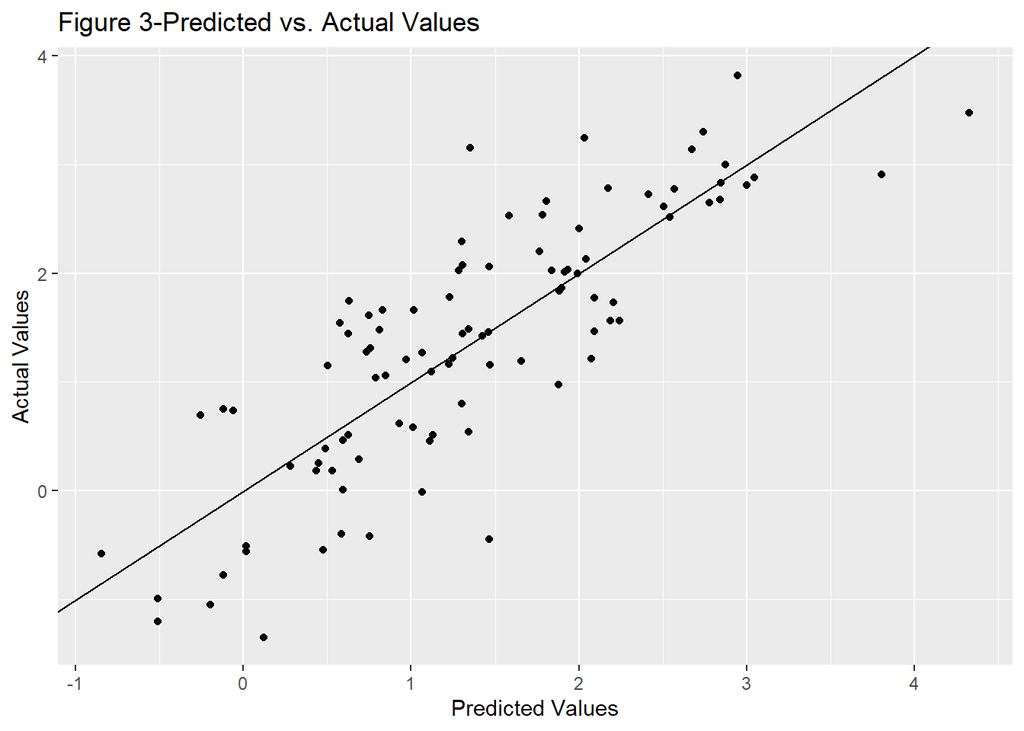

Figure 3 represents the comparison of the values of the prediction of lcavol against the true ones. So each point represent a value of lcavol by it prediction. we Can see also that we have a shape close to a line which means that this model is good-fit model for this data.

```r
library(ggplot2)
ggplot(pro, aes(x=predictedlcavol, y= lcavol)) +geom_point() +geom_abline(intercept=0, slope=1) +labs(x='Predicted Values', y='Actual Values', title='Figure 3-Predicted vs. Actual Values')
```

```r
residualss<- lcavol - predictedlcavol # error ( true values- predicted values)
head(residualss)
```

```
##          1          2          3          4          5          6
##  0.2694995 -0.4844369 -0.5273953 -0.6945717  0.8698524 -0.8527652
```

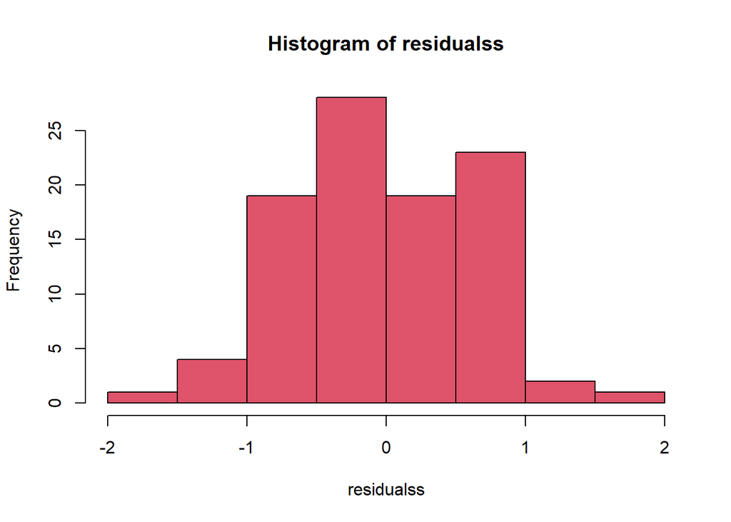

This figure represents the histogram of the residuals between lcavol and it’s prediction. we Can see in Histrogram of Residuals that we can have a bell-formed shape which means that Residuals are very close to have a normall distribution.

```r
hist(residualss, col=2)
```

```r
a=shapiro.test(residualss)
a
```

```
##
##  Shapiro-Wilk normality test
##
## data:  residualss
## W = 0.99026, p-value = 0.705
```

```r
SSW<-deviance(model) # residual sum of squares summation of (ei^2)
SSW
```

```
## [1] 41.81407
```

```r
R<-summary(model)$r.squared #it is close to 1, our model is a good fit for the data but it can be improved more.
R
```

```
## [1] 0.6864549
```

```r
models<- lm(formula= lcavol ~ lweight + age + lbph + prostateCancer$svi + prostateCancer$gleason + pgg45, data=pro)
summary(models)
```

```
##
## Call:
## lm(formula = lcavol ~ lweight + age + lbph + prostateCancer$svi +
##     prostateCancer$gleason + pgg45, data = pro)
##
## Residuals:
##      Min       1Q   Median       3Q      Max
## -1.84488 -0.48256 -0.01752  0.58918  2.21990
##
## Coefficients:
##                           Estimate Std. Error t value Pr(>|t|)
## (Intercept)             -1.9717103  1.1590310  -1.701 0.092442 .
## lweight                  0.5849583  0.2591548   2.257 0.026472 *
## age                      0.0072858  0.0146727   0.497 0.620739
## lbph                    -0.0746433  0.0771750  -0.967 0.336097
## prostateCancer$svi1      1.0245817  0.2714729   3.774 0.000291 ***
## prostateCancer$gleason7  0.8007406  0.2744312   2.918 0.004473 **
## prostateCancer$gleason8  0.6868720  0.9601171   0.715 0.476253
## prostateCancer$gleason9  1.1726480  0.6444380   1.820 0.072214 .
## pgg45                   -0.0004312  0.0056372  -0.076 0.939203
## ---
## Signif. codes:  0 '***' 0.001 '**' 0.01 '*' 0.05 '.' 0.1 ' ' 1
##
## Residual standard error: 0.9272 on 88 degrees of freedom
## Multiple R-squared:  0.4327, Adjusted R-squared:  0.3811
## F-statistic:  8.39 on 8 and 88 DF,  p-value: 2.11e-08
```

```r
summary(models)$r.squared # not better than the first model and it was expected because lpsa and lcp are significant variables
```

```
## [1] 0.4327101
```

To check if the residuals follow a normal distribution we did the shapiro test which is:
$$\begin{cases} H_{0}: Normally \ Distributed \\ \\ H_{1}: Not \ Normally \ Distribued \end{cases}$$
We can see that $p-value = 0.705$ which is greater than 0.05, then we fail to reject $H_{0}$, so they are normally distributed.

## (e)

If we looked at the value of $R^2$ we can see that it is 0.6864 and it is not too close to the value 1 but our model is good-fit model.

## (f)

If we removed the predictors lpsa and lcp and we look at the value of $R^2$ we can see that it decreased to 0.4327 so the new model doesn’t fit well the data and this was expected because the variables lpsa and lcp are significant.

## (a)

The goal of this section is to find the number of predictors that give us the lowest residual error. We will start by investigating some of the models with different number of predictors.

```r
#defining 3 different models
modelA<-lm(lcavol ~1,prostateCancer)
modelB<-lm(lcavol ~., prostateCancer[,c(1,4,9)])
modelC<-lm(lcavol ~., prostateCancer[,c(1,2,9)])
summary(modelA)
```

```
##
## Call:
## lm(formula = lcavol ~ 1, data = prostateCancer)
##
## Residuals:
##      Min       1Q   Median       3Q      Max
## -2.69708 -0.83719  0.09691  0.77703  2.47099
##
## Coefficients:
##             Estimate Std. Error t value Pr(>|t|)
## (Intercept)   1.3500     0.1197   11.28   <2e-16 ***
## ---
## Signif. codes:  0 '***' 0.001 '**' 0.01 '*' 0.05 '.' 0.1 ' ' 1
##
## Residual standard error: 1.179 on 96 degrees of freedom
```

```r
summary(modelB)
```

```
##
## Call:
## lm(formula = lcavol ~ ., data = prostateCancer[, c(1, 4, 9)])
##
## Residuals:
##     Min      1Q  Median      3Q     Max
## -2.2998 -0.6245  0.0414  0.5564  1.6266
##
## Coefficients:
##             Estimate Std. Error t value Pr(>|t|)
## (Intercept) -0.54900    0.19459  -2.821  0.00583 **
## lbph        -0.08791    0.05709  -1.540  0.12697
## lpsa         0.76979    0.07176  10.728  < 2e-16 ***
## ---
## Signif. codes:  0 '***' 0.001 '**' 0.01 '*' 0.05 '.' 0.1 ' ' 1
##
## Residual standard error: 0.7983 on 94 degrees of freedom
## Multiple R-squared:  0.5508, Adjusted R-squared:  0.5412
## F-statistic: 57.62 on 2 and 94 DF,  p-value: < 2.2e-16
```

```r
summary(modelC)
```

```
##
## Call:
## lm(formula = lcavol ~ ., data = prostateCancer[, c(1, 2, 9)])
##
## Residuals:
##      Min       1Q   Median       3Q      Max
## -2.06980 -0.60231  0.05406  0.53762  1.70037
##
## Coefficients:
##             Estimate Std. Error t value Pr(>|t|)
## (Intercept) -0.09570    0.71596  -0.134    0.894
## lweight     -0.12781    0.21327  -0.599    0.550
## lpsa         0.77047    0.07915   9.734 6.75e-16 ***
## ---
## Signif. codes:  0 '***' 0.001 '**' 0.01 '*' 0.05 '.' 0.1 ' ' 1
##
## Residual standard error: 0.8068 on 94 degrees of freedom
## Multiple R-squared:  0.5412, Adjusted R-squared:  0.5314
## F-statistic: 55.44 on 2 and 94 DF,  p-value: < 2.2e-16
```

```r
deviance(modelA)
```

```
## [1] 133.359
```

```r
deviance(modelB)
```

```
## [1] 59.90979
```

```r
deviance(modelC)
```

```
## [1] 61.18712
```

```r
resid0=sum(modelA$residuals^2); resid0
```

```
## [1] 133.359
```

- Model A represents a linear regression model without predictors, where the dependent variable is lcavol and value of $\beta_{0}$=1.35.
- Model B represents a multiple linear regression model where the dependent variable is lcavol and the independent variables are *lbph* and *lpsa* with predictors $\beta_{0}$=-0.549 $\beta_{1}$=-0.08791 $\beta_{2}$=0.76979.
- Model C represents a multiple linear regression model where the dependent variable is lcavol and the independent variables are *lweight* and *lpsa* with predictors $\beta_{0}$=-0.09570 $\beta_{1}$=-0.12781 $\beta_{2}$=0.77047.

Model A is using no predictors, the value of y predicted will be naturally just the mean of y, and we see that the residual is very high compared to a residual using only 2 predictors which make sense because the RSS decreases when we use more predictors because we have more information on the model. We also remark that Model B gives lower RSS than C.

## (b)

We want to find the optimal model for each k using the RSS, we will start by computing the residual error for all models containing exactly two predictors(k = 2) and choose the one who has the minimal error.

```r
resid1 <- rep(0,28)
counter = 1
for (i in 2:8){
  for (j in (i+1):9){
    Model1<-lm(lcavol~ pro[,i]+pro[,j])
    resid1[counter] = sum(Model1$residuals^2)
    counter = counter + 1
  }
}
resid1 # residual sum for all possible models of K=2
```

```
##  [1] 120.40250 121.31398  89.34527  68.60765  99.65994 100.89503  61.18712
##  [8] 126.20551  91.10619  69.93021 106.72359 106.68069  60.03570  93.90983
## [15]  72.40419 108.41763 108.27432  59.90979  70.80917  84.60942  88.73558
## [22]  58.45219  71.23821  72.52999  47.27810 104.80986  57.39883  58.94625
```

```r
index1 = which.min(resid1);index1    # i=6 and j=9
```

```
## [1] 25
```

So we found out that the best selection model is the model with **lcp** and **lpsa** as independent variables.

## (c)

Here, we do the same thing as before but for k ranging from 0 to 8

```r
resi = rep(0,9)
optimal = list()
model<-lm(lcavol ~1,pro)
resi[1] = sum(model$residuals^2)
for (k in 1 : 8){
  # We take all the combinations of k in 8
  a = combn(8,k,simplify = TRUE) + 1 # we add 1 to take only the predictor variables
  # minimum of RSS for k predictors
  min = 2^10
  # we create list of indexes of the linear regression columns
  for (i in 1:ncol(a)){
    combination = a[,i]
    q = rep(1,k+1)
    for (j in 1 : k){
      q[j+1] = combination[j]
    }
    model = lm(lcavol ~ .,data = pro[q])
    error = sum(model$residuals^2)
    # Here, we save the minimal error and the indexes that satisfy it
    if (error < min){
      min = error;
      resi[k+1] = min
      best = combination
    }
  }
  optimal[[k]] = best
  cat('The best predictors for k = ',k,'are : ',colnames(pro[best]),',and the error associated is ',min,'\n')

}
```

```
## The best predictors for k =  1 are :  lpsa ,and the error associated is  61.42091
## The best predictors for k =  2 are :  lcp lpsa ,and the error associated is  47.2781
## The best predictors for k =  3 are :  age lcp lpsa ,and the error associated is  46.23783
## The best predictors for k =  4 are :  age lbph lcp lpsa ,and the error associated is  44.87841
## The best predictors for k =  5 are :  age lbph lcp pgg45 lpsa ,and the error associated is  44.31133
## The best predictors for k =  6 are :  age lbph lcp gleason pgg45 lpsa ,and the error associated is  43.35425
## The best predictors for k =  7 are :  age lbph svi lcp gleason pgg45 lpsa ,and the error associated is  43.17905
## The best predictors for k =  8 are :  lweight age lbph svi lcp gleason pgg45 lpsa ,and the error associated is  43.1717
```

```r
predictors = rep(0,9)
for (i in 0:8){
  predictors[i+1] = i
}
```

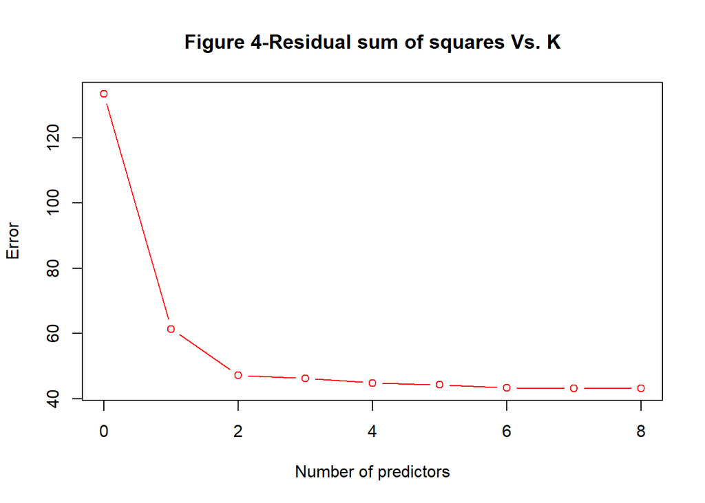

Figure 4 represents the number of predictors used with the least error for all models having K predictors, we Can see that as the number of predictors is icreasing the error is decreasing which makes sense because we’re adding more information to our model so it will become more accurate. But this creates a limitation when wanting to choose the best model.

```r
plot(predictors,resi,  type='b', xlab="Number of predictors", ylab="Error", main="Figure 4-Residual sum of squares Vs. K", axes=TRUE, col="red")
```

## (d)

The best subset selection method can be used only to compare and choose best model for each value of K, so at the end we will have the best predictors that correspond to the best variables for each value of K. Moreover, To choose the best model among the best predictors for each value of K, we need to use the split-Validation method because we need to compare models with different number of predictors and the residual error is only good when comparing models with the same number of predictors. So we will try to perform a cross validation on our models that we found in the next section.

## (a)

It involves randomly dividing the available set of observations into two parts, a training set and a validation set or hold-out set. The validation set hold-out set model is fit on the training set, and the fitted model is used to predict the responses for the observations in the validation set. The resulting validation set error rate—typically assessed using MSE in the case of a quantitative response—provides an estimate of the test error rate.So, in Case of Split Validation, we have different issues than best subset selection, where in this method we can select the best model used for different number of predictors. Finally, both test error and training error analysis will help us to determine the best model for our data.

In this example, we choose the validation set to be the data lines which index is multiples of 3, and the training set will be the rest. Here we define the indexes of both sets(true for validation set and false value for training set).

```r
# create matrix of validation set where it is the line for which the index is a multiple of 3
valid <- 1:nrow(pro) %% 3 == 0
valid
```

```
##  [1] FALSE FALSE  TRUE FALSE FALSE  TRUE FALSE FALSE  TRUE FALSE FALSE  TRUE
## [13] FALSE FALSE  TRUE FALSE FALSE  TRUE FALSE FALSE  TRUE FALSE FALSE  TRUE
## [25] FALSE FALSE  TRUE FALSE FALSE  TRUE FALSE FALSE  TRUE FALSE FALSE  TRUE
## [37] FALSE FALSE  TRUE FALSE FALSE  TRUE FALSE FALSE  TRUE FALSE FALSE  TRUE
## [49] FALSE FALSE  TRUE FALSE FALSE  TRUE FALSE FALSE  TRUE FALSE FALSE  TRUE
## [61] FALSE FALSE  TRUE FALSE FALSE  TRUE FALSE FALSE  TRUE FALSE FALSE  TRUE
## [73] FALSE FALSE  TRUE FALSE FALSE  TRUE FALSE FALSE  TRUE FALSE FALSE  TRUE
## [85] FALSE FALSE  TRUE FALSE FALSE  TRUE FALSE FALSE  TRUE FALSE FALSE  TRUE
## [97] FALSE
```

## (b)

```r
# We train the training set data using the two optimal predictors found previously in the subset selection. We use the data that's not in the validation set.
i = 6
j = 9
model = lm(lcavol ~., data=pro[!valid, c(1,i, j)])
summary(model)
```

```
##
## Call:
## lm(formula = lcavol ~ ., data = pro[!valid, c(1, i, j)])
##
## Residuals:
##      Min       1Q   Median       3Q      Max
## -1.11959 -0.57345 -0.08939  0.62260  1.97063
##
## Coefficients:
##             Estimate Std. Error t value Pr(>|t|)
## (Intercept) -0.10264    0.25189  -0.407   0.6851
## lcp          0.24836    0.07473   3.323   0.0015 **
## lpsa         0.60261    0.09289   6.488 1.64e-08 ***
## ---
## Signif. codes:  0 '***' 0.001 '**' 0.01 '*' 0.05 '.' 0.1 ' ' 1
##
## Residual standard error: 0.6957 on 62 degrees of freedom
## Multiple R-squared:  0.6682, Adjusted R-squared:  0.6575
## F-statistic: 62.43 on 2 and 62 DF,  p-value: 1.405e-15
```

```r
cat("The residual sum of the data is : \n")
```

```
## The residual sum of the data is :
```

```r
sum(model$residuals**2)
```

```
## [1] 30.00831
```

```r
variance = function(fit, validation=F) {
  if (validation) {
    l = var(predict.lm(fit, pro[!!valid, ]) - pro[!!valid, 1])
  }
  else {
    l = var(predict.lm(fit, pro[!valid, ]) - pro[!valid, 1])
  }
  l
}
cat("The variance of residuals for training set is: \n")
```

```
## The variance of residuals for training set is:
```

```r
variance(model)
```

```
## [1] 0.4688799
```

```r
cat("The variance of residuals for validation set is: \n")
```

```
## The variance of residuals for validation set is:
```

```r
variance(model, validation = TRUE)
```

```
## [1] 0.5853993
```

In this model we are performing a multiple linear regression on the dependent variable lcavol using the independent variables lcp and lpsa where the data is not the valid one (not multiples of 3).

## (c)

```r
# calculate the fitting parameters of the training set and then fit them in the validation
predicted = predict(model, newdata = pro[valid,c(1,i,j)])
cat("The test error is : \n")
```

```
## The test error is :
```

```r
sum((predicted - pro[valid,c(1)])**2)  # error of validation set
```

```
## [1] 18.15137
```